# House Price Analyses

# Introduction

This analysis will focus on building a regression model to predict house sale prices using Kaggle data. The process involves identifying key predictors, interpreting their impact, and validating the model.

## Model Creation

```r
library(tidyverse)
library(dplyr)
library(pander)

train = read.csv("train.csv", stringsAsFactors = TRUE)
```

The first thing I did was look at the pairs plot to see all notable patterns that had good slop.

This is what I found:

Slopes that look like they could be useful:

- GarageArea
- KitchenQual
- TotRmsAbvGrd
- GrLivArea
- X2ndFlrSF
- X1stFlrSF
- TotalBsmtSF
- MasVnrType
- OverallQual

Smaller but potentially useful slops:

- SaleCondition
- MiscFeature
- EnclosedPorch
- PavedDrive
- GarageYrBlt
- GarageFinish
- FullBath
- BsmtUnfSF
- BsmtQual
- ExterQual

[figure not shown]

After that I looked at the data dictionary and looked for stuff that seemed like it might be useful logicly.

Here is what I found:

This could help with location

- MSZoning

Both could have a lot of variables wrapped into one

- OverallQual
- OverallCond

This could show economic things because of timing

- YearBuilt
- YearRemodAdd
- YrSold
- MoSold

This might be able to show how having a basement/finished basement contributes

- BsmtFinSF1
- BsmtUnfSF

The number of baths total could be useful

- BsmtFullBath
- BsmtHalfBath
- FullBath
- HalfBath

I then used all of that new knowledge I found and starting making linear models. These models had various success rates. Bellow you can see a sample of some of the models I tried.

```r
mylm1 = lm(SalePrice ~ GarageArea + KitchenQual + TotRmsAbvGrd + GrLivArea + OverallQual, data = train)
pander(summary(mylm1))
```

|  | Estimate | Std. Error | t value | Pr(>\|t\|) |
| --- | --- | --- | --- | --- |
| **(Intercept)** | 9356 | 9630 | 0.9716 | 0.3314 |
| **GarageArea** | 63.35 | 5.901 | 10.74 | 6.338e-26 |
| **KitchenQualFa** | -69519 | 8249 | -8.428 | 8.372e-17 |
| **KitchenQualGd** | -53291 | 4413 | -12.08 | 4.637e-32 |
| **KitchenQualTA** | -68226 | 5046 | -13.52 | 2.526e-39 |
| **TotRmsAbvGrd** | -1757 | 1110 | -1.583 | 0.1136 |
| **GrLivArea** | 52.89 | 3.899 | 13.57 | 1.47e-39 |
| **OverallQual** | 21394 | 1146 | 18.68 | 6.296e-70 |

Fitting linear model: SalePrice ~ GarageArea + KitchenQual + TotRmsAbvGrd + GrLivArea + OverallQual

| Observations | Residual Std. Error | $R^2$ | Adjusted $R^2$ |
| --- | --- | --- | --- |
| 1460 | 38268 | 0.7691 | 0.768 |

```r
mylm2 = lm(SalePrice ~ SaleCondition + X2ndFlrSF + X1stFlrSF + TotalBsmtSF, data = train)
pander(summary(mylm2))
```

|  | Estimate | Std. Error | t value | Pr(>\|t\|) |
| --- | --- | --- | --- | --- |
| **(Intercept)** | -27636 | 6172 | -4.478 | 8.143e-06 |
| **SaleConditionAdjLand** | 6546 | 24018 | 0.2725 | 0.7852 |
| **SaleConditionAlloca** | 7555 | 14605 | 0.5173 | 0.605 |
| **SaleConditionFamily** | -9272 | 11519 | -0.8049 | 0.421 |
| **SaleConditionNormal** | 21874 | 4877 | 4.485 | 7.865e-06 |
| **SaleConditionPartial** | 69847 | 6432 | 10.86 | 1.829e-26 |
| **X2ndFlrSF** | 82.07 | 2.889 | 28.41 | 1.558e-141 |
| **X1stFlrSF** | 82.13 | 5.689 | 14.44 | 3.08e-44 |
| **TotalBsmtSF** | 57.42 | 5.041 | 11.39 | 7.594e-29 |

Fitting linear model: SalePrice ~ SaleCondition + X2ndFlrSF + X1stFlrSF + TotalBsmtSF

| Observations | Residual Std. Error | $R^2$ | Adjusted $R^2$ |
| --- | --- | --- | --- |
| 1460 | 47039 | 0.6513 | 0.6494 |

```r
mylm3 = lm(SalePrice ~ OverallQual + OverallCond + YearBuilt + YearRemodAdd + YrSold + MoSold, data = train)
pander(summary(mylm3))
```

|  | Estimate | Std. Error | t value | Pr(>\|t\|) |
| --- | --- | --- | --- | --- |
| **(Intercept)** | 499204 | 1924199 | 0.2594 | 0.7953 |
| **OverallQual** | 40654 | 1175 | 34.61 | 6.353e-192 |
| **OverallCond** | 985.9 | 1330 | 0.7415 | 0.4585 |
| **YearBuilt** | 217.5 | 64.37 | 3.379 | 0.0007474 |
| **YearRemodAdd** | 261.5 | 85.98 | 3.041 | 0.0024 |
| **YrSold** | -756 | 958.9 | -0.7885 | 0.4306 |
| **MoSold** | -234 | 471.2 | -0.4967 | 0.6195 |

Fitting linear model: SalePrice ~ OverallQual + OverallCond + YearBuilt + YearRemodAdd + YrSold + MoSold

| Observations | Residual Std. Error | $R^2$ | Adjusted $R^2$ |
| --- | --- | --- | --- |
| 1460 | 48001 | 0.6364 | 0.6349 |

```r
mylm4 = lm(SalePrice ~ BsmtFullBath + BsmtHalfBath + FullBath + HalfBath, data = train)
pander(summary(mylm4))
```

|  | Estimate | Std. Error | t value | Pr(>\|t\|) |
| --- | --- | --- | --- | --- |
| **(Intercept)** | 23972 | 5092 | 4.708 | 2.739e-06 |
| **BsmtFullBath** | 42546 | 3063 | 13.89 | 2.813e-41 |
| **BsmtHalfBath** | 18980 | 6652 | 2.853 | 0.004389 |
| **FullBath** | 79592 | 2883 | 27.61 | 2.954e-135 |
| **HalfBath** | 34458 | 3147 | 10.95 | 7.276e-27 |

Fitting linear model: SalePrice ~ BsmtFullBath + BsmtHalfBath + FullBath + HalfBath

| Observations | Residual Std. Error | $R^2$ | Adjusted $R^2$ |
| --- | --- | --- | --- |
| 1460 | 59871 | 0.4336 | 0.432 |

```r
mylm5 = lm(SalePrice ~ OverallQual:KitchenQual:OverallCond, data = train)
pander(summary(mylm5))
```

Table continues below

|  | Estimate | Std. Error | t value |
| --- | --- | --- | --- |
| **(Intercept)** | 77804 | 5902 | 13.18 |
| **OverallQual:KitchenQualEx:OverallCond** | 5712 | 178.2 | 32.05 |
| **OverallQual:KitchenQualFa:OverallCond** | 1259 | 359 | 3.506 |
| **OverallQual:KitchenQualGd:OverallCond** | 3581 | 162.8 | 21.99 |
| **OverallQual:KitchenQualTA:OverallCond** | 2068 | 193 | 10.71 |

|  | Pr(>\|t\|) |
| --- | --- |
| **(Intercept)** | 1.421e-37 |
| **OverallQual:KitchenQualEx:OverallCond** | 5.574e-171 |
| **OverallQual:KitchenQualFa:OverallCond** | 0.0004687 |
| **OverallQual:KitchenQualGd:OverallCond** | 9.659e-93 |
| **OverallQual:KitchenQualTA:OverallCond** | 7.801e-26 |

Fitting linear model: SalePrice ~ OverallQual:KitchenQual:OverallCond

| Observations | Residual Std. Error | $R^2$ | Adjusted $R^2$ |
| --- | --- | --- | --- |
| 1460 | 53992 | 0.5394 | 0.5381 |

After trying those, I finally thought to use the variables we did in class, as well as combining columns to perhaps make my own new columns.

You can see below what I did.

```r
train <- train %>%
  mutate(TotalSF = X1stFlrSF + X2ndFlrSF + TotalBsmtSF)

train <- train %>%
  mutate(Totalbaths = BsmtFullBath + BsmtHalfBath + FullBath + HalfBath)

train <- train %>%
  mutate(renovatedyn = ifelse(YearRemodAdd == YearBuilt, "No", "Yes"))

train <- train %>%
  mutate(age_at_sale = YrSold - YearBuilt)

train <- train %>%
  mutate(RichNbrhd = case_when(Neighborhood %in% c("StoneBr", "NridgHt", "NoRidge") ~ 1,
                             TRUE ~ 0))
train <- train %>%
  mutate(OverallQual_group = ifelse(OverallQual <= 5, 5, OverallQual))
```

```r
mylm6 = lm(SalePrice ~ TotalSF, data = train)
pander(summary(mylm6))
```

|  | Estimate | Std. Error | t value | Pr(>\|t\|) |
| --- | --- | --- | --- | --- |
| **(Intercept)** | -13220 | 4251 | -3.11 | 0.001909 |
| **TotalSF** | 75.63 | 1.577 | 47.95 | 5.511e-302 |

Fitting linear model: SalePrice ~ TotalSF

| Observations | Residual Std. Error | $R^2$ | Adjusted $R^2$ |
| --- | --- | --- | --- |
| 1460 | 49506 | 0.6119 | 0.6117 |

```r
mylm7 = lm(SalePrice ~ TotalSF + Totalbaths + MSZoning + renovatedyn + age_at_sale, data = train)
pander(summary(mylm7))
```

|  | Estimate | Std. Error | t value | Pr(>\|t\|) |
| --- | --- | --- | --- | --- |
| **(Intercept)** | -5369 | 14760 | -0.3638 | 0.7161 |
| **TotalSF** | 58.5 | 1.727 | 33.87 | 8.489e-186 |
| **Totalbaths** | 10425 | 1650 | 6.319 | 3.505e-10 |
| **MSZoningFV** | 34099 | 15104 | 2.258 | 0.02412 |
| **MSZoningRH** | 15329 | 17441 | 0.8789 | 0.3796 |
| **MSZoningRL** | 29896 | 13917 | 2.148 | 0.03186 |
| **MSZoningRM** | 24092 | 13999 | 1.721 | 0.08546 |
| **renovatedynYes** | 18960 | 2534 | 7.483 | 1.25e-13 |
| **age_at_sale** | -742.2 | 50.87 | -14.59 | 4.316e-45 |

Fitting linear model: SalePrice ~ TotalSF + Totalbaths + MSZoning + renovatedyn + age_at_sale

| Observations | Residual Std. Error | $R^2$ | Adjusted $R^2$ |
| --- | --- | --- | --- |
| 1460 | 43188 | 0.7061 | 0.7045 |

```r
mylm8 = lm(SalePrice ~ TotalSF + OverallQual + Totalbaths + MSZoning + renovatedyn + YearBuilt + age_at_sale, data = train)
pander(summary(mylm8))
```

|  | Estimate | Std. Error | t value | Pr(>\|t\|) |
| --- | --- | --- | --- | --- |
| **(Intercept)** | 292076 | 1525175 | 0.1915 | 0.8482 |
| **TotalSF** | 38.58 | 1.835 | 21.03 | 6.996e-86 |
| **OverallQual** | 22794 | 1150 | 19.82 | 1.596e-77 |
| **Totalbaths** | 9224 | 1468 | 6.284 | 4.347e-10 |
| **MSZoningFV** | 6077 | 13482 | 0.4507 | 0.6522 |
| **MSZoningRH** | 1587 | 15507 | 0.1023 | 0.9185 |
| **MSZoningRL** | 14203 | 12380 | 1.147 | 0.2515 |
| **MSZoningRM** | 590 | 12488 | 0.04725 | 0.9623 |
| **renovatedynYes** | 13229 | 2267 | 5.834 | 6.654e-09 |
| **YearBuilt** | -188.5 | 759.6 | -0.2481 | 0.8041 |
| **age_at_sale** | -491.5 | 757.5 | -0.6488 | 0.5165 |

Fitting linear model: SalePrice ~ TotalSF + OverallQual + Totalbaths + MSZoning + renovatedyn + YearBuilt + age_at_sale

| Observations | Residual Std. Error | $R^2$ | Adjusted $R^2$ |
| --- | --- | --- | --- |
| 1460 | 38334 | 0.7687 | 0.7672 |

I then looked over all my models and choice the following model.

Model Summary:

```r
mylm_80 = lm(SalePrice ~ RichNbrhd*TotalSF*as.factor(OverallQual_group) + YearBuilt, data = train)
pander(summary(mylm_80))
```

Table continues below

|  | Estimate | Std. Error |
| --- | --- | --- |
| **(Intercept)** | -694411 | 61187 |
| **RichNbrhd** | -568990 | 47159 |
| **TotalSF** | 33.76 | 2.194 |
| **as.factor(OverallQual_group)6** | -13805 | 8351 |
| **as.factor(OverallQual_group)7** | -22768 | 10043 |
| **as.factor(OverallQual_group)8** | -26973 | 17308 |
| **as.factor(OverallQual_group)9** | -48468 | 112525 |
| **as.factor(OverallQual_group)10** | 418510 | 28134 |
| **YearBuilt** | 384.2 | 31.3 |
| **RichNbrhd:TotalSF** | 148.3 | 8.66 |
| **RichNbrhd:as.factor(OverallQual_group)6** | 733242 | 974427 |
| **RichNbrhd:as.factor(OverallQual_group)7** | 487985 | 60834 |
| **RichNbrhd:as.factor(OverallQual_group)8** | 570124 | 53513 |
| **RichNbrhd:as.factor(OverallQual_group)9** | 397519 | 128680 |
| **TotalSF:as.factor(OverallQual_group)6** | 12.83 | 3.509 |
| **TotalSF:as.factor(OverallQual_group)7** | 23.17 | 3.782 |
| **TotalSF:as.factor(OverallQual_group)8** | 32.17 | 5.52 |
| **TotalSF:as.factor(OverallQual_group)9** | 50.69 | 31.94 |
| **TotalSF:as.factor(OverallQual_group)10** | -64.14 | 4.555 |
| **RichNbrhd:TotalSF:as.factor(OverallQual_group)6** | -206.5 | 364.8 |
| **RichNbrhd:TotalSF:as.factor(OverallQual_group)7** | -118.2 | 15.29 |
| **RichNbrhd:TotalSF:as.factor(OverallQual_group)8** | -143.5 | 11.32 |
| **RichNbrhd:TotalSF:as.factor(OverallQual_group)9** | -98.19 | 34.61 |

|  | t value | Pr(>\|t\|) |
| --- | --- | --- |
| **(Intercept)** | -11.35 | 1.195e-28 |
| **RichNbrhd** | -12.07 | 5.353e-32 |
| **TotalSF** | 15.39 | 1.436e-49 |
| **as.factor(OverallQual_group)6** | -1.653 | 0.09853 |
| **as.factor(OverallQual_group)7** | -2.267 | 0.02354 |
| **as.factor(OverallQual_group)8** | -1.558 | 0.1194 |
| **as.factor(OverallQual_group)9** | -0.4307 | 0.6667 |
| **as.factor(OverallQual_group)10** | 14.88 | 1.162e-46 |
| **YearBuilt** | 12.27 | 5.277e-33 |
| **RichNbrhd:TotalSF** | 17.13 | 5.419e-60 |
| **RichNbrhd:as.factor(OverallQual_group)6** | 0.7525 | 0.4519 |
| **RichNbrhd:as.factor(OverallQual_group)7** | 8.022 | 2.147e-15 |
| **RichNbrhd:as.factor(OverallQual_group)8** | 10.65 | 1.46e-25 |
| **RichNbrhd:as.factor(OverallQual_group)9** | 3.089 | 0.002045 |
| **TotalSF:as.factor(OverallQual_group)6** | 3.657 | 0.0002647 |
| **TotalSF:as.factor(OverallQual_group)7** | 6.128 | 1.151e-09 |
| **TotalSF:as.factor(OverallQual_group)8** | 5.828 | 6.917e-09 |
| **TotalSF:as.factor(OverallQual_group)9** | 1.587 | 0.1127 |
| **TotalSF:as.factor(OverallQual_group)10** | -14.08 | 2.864e-42 |
| **RichNbrhd:TotalSF:as.factor(OverallQual_group)6** | -0.5661 | 0.5714 |
| **RichNbrhd:TotalSF:as.factor(OverallQual_group)7** | -7.726 | 2.077e-14 |
| **RichNbrhd:TotalSF:as.factor(OverallQual_group)8** | -12.67 | 5.661e-35 |
| **RichNbrhd:TotalSF:as.factor(OverallQual_group)9** | -2.837 | 0.004615 |

Fitting linear model: SalePrice ~ RichNbrhd * TotalSF * as.factor(OverallQual_group) + YearBuilt

| Observations | Residual Std. Error | $R^2$ | Adjusted $R^2$ |
| --- | --- | --- | --- |
| 1460 | 28884 | 0.8698 | 0.8678 |

## Model and Valadation

Bellow is the model I choice to use for the purposes of this analyses.

```r
mylm_80 = lm(SalePrice ~ RichNbrhd*TotalSF*as.factor(OverallQual_group) + YearBuilt, data = train)
pander(summary(mylm_80))
```

Table continues below

|  | Estimate | Std. Error |
| --- | --- | --- |
| **(Intercept)** | -694411 | 61187 |
| **RichNbrhd** | -568990 | 47159 |
| **TotalSF** | 33.76 | 2.194 |
| **as.factor(OverallQual_group)6** | -13805 | 8351 |
| **as.factor(OverallQual_group)7** | -22768 | 10043 |
| **as.factor(OverallQual_group)8** | -26973 | 17308 |
| **as.factor(OverallQual_group)9** | -48468 | 112525 |
| **as.factor(OverallQual_group)10** | 418510 | 28134 |
| **YearBuilt** | 384.2 | 31.3 |
| **RichNbrhd:TotalSF** | 148.3 | 8.66 |
| **RichNbrhd:as.factor(OverallQual_group)6** | 733242 | 974427 |
| **RichNbrhd:as.factor(OverallQual_group)7** | 487985 | 60834 |
| **RichNbrhd:as.factor(OverallQual_group)8** | 570124 | 53513 |
| **RichNbrhd:as.factor(OverallQual_group)9** | 397519 | 128680 |
| **TotalSF:as.factor(OverallQual_group)6** | 12.83 | 3.509 |
| **TotalSF:as.factor(OverallQual_group)7** | 23.17 | 3.782 |
| **TotalSF:as.factor(OverallQual_group)8** | 32.17 | 5.52 |
| **TotalSF:as.factor(OverallQual_group)9** | 50.69 | 31.94 |
| **TotalSF:as.factor(OverallQual_group)10** | -64.14 | 4.555 |
| **RichNbrhd:TotalSF:as.factor(OverallQual_group)6** | -206.5 | 364.8 |
| **RichNbrhd:TotalSF:as.factor(OverallQual_group)7** | -118.2 | 15.29 |
| **RichNbrhd:TotalSF:as.factor(OverallQual_group)8** | -143.5 | 11.32 |
| **RichNbrhd:TotalSF:as.factor(OverallQual_group)9** | -98.19 | 34.61 |

|  | t value | Pr(>\|t\|) |
| --- | --- | --- |
| **(Intercept)** | -11.35 | 1.195e-28 |
| **RichNbrhd** | -12.07 | 5.353e-32 |
| **TotalSF** | 15.39 | 1.436e-49 |
| **as.factor(OverallQual_group)6** | -1.653 | 0.09853 |
| **as.factor(OverallQual_group)7** | -2.267 | 0.02354 |
| **as.factor(OverallQual_group)8** | -1.558 | 0.1194 |
| **as.factor(OverallQual_group)9** | -0.4307 | 0.6667 |
| **as.factor(OverallQual_group)10** | 14.88 | 1.162e-46 |
| **YearBuilt** | 12.27 | 5.277e-33 |
| **RichNbrhd:TotalSF** | 17.13 | 5.419e-60 |
| **RichNbrhd:as.factor(OverallQual_group)6** | 0.7525 | 0.4519 |
| **RichNbrhd:as.factor(OverallQual_group)7** | 8.022 | 2.147e-15 |
| **RichNbrhd:as.factor(OverallQual_group)8** | 10.65 | 1.46e-25 |
| **RichNbrhd:as.factor(OverallQual_group)9** | 3.089 | 0.002045 |
| **TotalSF:as.factor(OverallQual_group)6** | 3.657 | 0.0002647 |
| **TotalSF:as.factor(OverallQual_group)7** | 6.128 | 1.151e-09 |
| **TotalSF:as.factor(OverallQual_group)8** | 5.828 | 6.917e-09 |
| **TotalSF:as.factor(OverallQual_group)9** | 1.587 | 0.1127 |
| **TotalSF:as.factor(OverallQual_group)10** | -14.08 | 2.864e-42 |
| **RichNbrhd:TotalSF:as.factor(OverallQual_group)6** | -0.5661 | 0.5714 |
| **RichNbrhd:TotalSF:as.factor(OverallQual_group)7** | -7.726 | 2.077e-14 |
| **RichNbrhd:TotalSF:as.factor(OverallQual_group)8** | -12.67 | 5.661e-35 |
| **RichNbrhd:TotalSF:as.factor(OverallQual_group)9** | -2.837 | 0.004615 |

Fitting linear model: SalePrice ~ RichNbrhd * TotalSF * as.factor(OverallQual_group) + YearBuilt

| Observations | Residual Std. Error | $R^2$ | Adjusted $R^2$ |
| --- | --- | --- | --- |
| 1460 | 28884 | 0.8698 | 0.8678 |

#### Vizulization of my model:

```r
# ggplot(train, aes(y = SalePrice, x =  TotalSF, color = as.factor(RichNbrhd))) +
#   geom_point() +
#   facet_wrap(~OverallQual_group) +
#   geom_line(aes(y = mylm_80$fitted))

# ggplot(train, aes(y = SalePrice, x = TotalSF,
#                   color = as.factor(RichNbrhd),
#                   size = YearBuilt)) +
#   geom_point() +
#   facet_wrap(~OverallQual_group) +
#   geom_line(aes(y = mylm_80$fitted), size = 1)  # Ensures line has a fixed size
```

```r
train <- train %>%
  mutate(YearBuilt_group = ifelse(YearBuilt < 1900, "Pre-1900",
                           ifelse(YearBuilt < 1920, "1900s",
                           ifelse(YearBuilt < 1940, "1920s-30s",
                           ifelse(YearBuilt < 1960, "1940s-50s",
                           ifelse(YearBuilt < 1980, "1960s-70s",
                           ifelse(YearBuilt < 2000, "1980s-90s",
                                                   "2000s-2010s")))))))
```

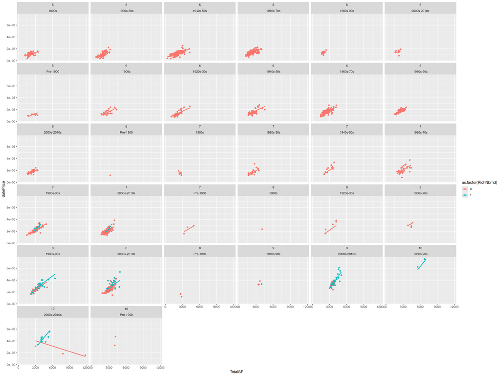

```r
ggplot(train, aes(y = SalePrice, x = TotalSF,
                  color = as.factor(RichNbrhd))) +
  geom_point() +
  facet_wrap(~OverallQual_group + YearBuilt_group) +  # Facet by both OverallQual_group and decade
  geom_line(aes(y = mylm_80$fitted), size = 1)  # Ensures line has a fixed size
```

```r
set.seed(121)
num_rows <- 1000 #1460 total
keep <- sample(1:nrow(train), num_rows)

mytrain <- train[keep, ] #Use this in the lm(..., data=mytrain) it is like "rbdata"
mytest <- train[-keep, ] #Use this in the predict(..., newdata=mytest) it is like "rbdata2"


mylm_80 = lm(SalePrice ~ RichNbrhd*TotalSF*as.factor(OverallQual_group) + YearBuilt, data = train)
# pander(summary(mylm_80))

yh_mylm_80 <- predict(mylm_80, newdata=mytest)
ybar <- mean(mytest$SalePrice)
SSTO <- sum( (mytest$SalePrice - ybar)^2 )
SSE_mylm_80 <- sum((mytest$SalePrice - yh_mylm_80)^2)
rs_mylm_80 <- 1 - SSE_mylm_80/SSTO

n <- nrow(mytest)
p_mylm_80 <- length(mylm_80)
p_mylm_80 <- length(coef(mylm_80)) # Number of estimated coefficients

rsa_mylm_80 <- 1 - ((n - 1) / (n - p_mylm_80)) * SSE_mylm_80 / SSTO
# rsa_mylm_80
# summary(mylm_80)

my_output_table2 <- data.frame(Model = c("My Model"),
`Original R2` = c(summary(mylm_80)$r.squared),
`Orig. Adj. R-squared` = c(summary(mylm_80)$adj.r.squared),

`Validation R-squared` = c(rs_mylm_80),
`Validation Adj. R^2` = c(rsa_mylm_80))

colnames(my_output_table2) <- c("Model", "Original $R^2$", "Original Adj. $R^2$", "Validation $R^2$", "Validation Adj. $R^2$")

knitr::kable(my_output_table2, escape=TRUE, digits=4)
```

| Model | Original $R^2$ | Original Adj. $R^2$ | Validation $R^2$ | Validation Adj. $R^2$ |
| --- | --- | --- | --- | --- |
| My Model | 0.8698 | 0.8678 | 0.8727 | 0.8657 |

## Interpretation

Below is the visualization of the model, where each line represents the different types of houses that the model takes into account.

For example, if a house has an Overall Quality score of 9, a rich neighborhood rating of 1, and a year built of, say, 2000, then you would look at the blue line for the chart labeled 9, 2000s-2010s. From there, you would find the total square footage of your house on the x-axis and then locate the estimated sales price on the y-axis. By doing all of this, you would have a pretty good idea of what your house might sell for.

Because TotalSF is the on the x-axis anything the only thing that effects the slop is TotalSF and all the things interacts with it. Everything else will be changing the intercept.

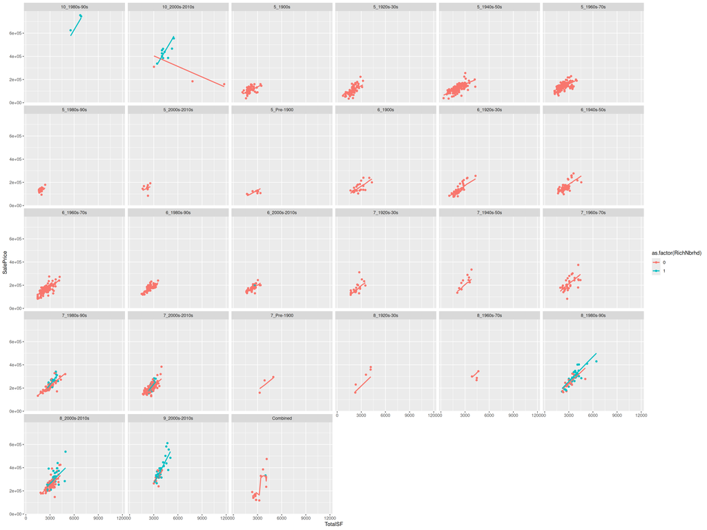

```r
# ggplot(train, aes(y = SalePrice, x = TotalSF,
#                   color = as.factor(RichNbrhd))) +
#   geom_point() +
#   facet_wrap(~OverallQual_group + YearBuilt_group) +
#   geom_line(aes(y = mylm_80$fitted), size = 1)

train <- train %>%
  mutate(YearBuilt_group = case_when(
    YearBuilt < 1900 ~ "Pre-1900",
    YearBuilt < 1920 ~ "1900s",
    YearBuilt < 1940 ~ "1920s-30s",
    YearBuilt < 1960 ~ "1940s-50s",
    YearBuilt < 1980 ~ "1960s-70s",
    YearBuilt < 2000 ~ "1980s-90s",
    TRUE ~ "2000s-2010s"
  ),
  OverallQual_group = case_when(
    OverallQual <= 5 ~ 5,
    TRUE ~ OverallQual
  ),
  Combined_Group = case_when(
    (OverallQual == 8 & YearBuilt_group == "1900s") |
    (OverallQual == 9 & YearBuilt_group %in% c("Pre-1900", "1900s", "1920s-30s", "1940s-50s", "1960s-70s", "1980s-90s")) |
    (OverallQual == 8 & YearBuilt_group == "Pre-1900") |
    (OverallQual == 7 & YearBuilt_group == "1900s") |
    (OverallQual == 6 & YearBuilt_group == "Pre-1900") |
    (OverallQual == 10 & YearBuilt_group == "Pre-1900") ~ "Combined",
    TRUE ~ paste(OverallQual_group, YearBuilt_group, sep = "_")
  ))

ggplot(train, aes(y = SalePrice, x = TotalSF, color = as.factor(RichNbrhd))) +
  geom_point() +
  facet_wrap(~ Combined_Group) +
  geom_line(aes(y = mylm_80$fitted), size = 1)
```

*I had to combine some of the categories because of lack of data.